# Graficas

Fernando Vazquez

4/14/2020

## Graficos con la funcion `plot`

- Con la funcion `plot(x,y)` podemos representar un grafico **basico** de puntos, siendo $x$ & $y$ vectores numericos .
  - plot(x) = plot(1:length(x),x)
- Cabe mencionar que con `plot(x,funcion)` podemos mandar a dibujar el grafico de una funcion.

# PARAMETROS DE LA FUNCION `PLOT()`

- `log` - Nos sirve para indicar que queremos el grafico en escala logaritmica.
- `main("Ttile")` - Nos sirve para ponerle titulo al grafico.
- `xlab("Etiqueta")` - Sirve para ponerle una etiqueta al eje $X$
- `ylab("Etiqueta")`- Sirve para ponerle una etiqueta al eje $Y$
- `pch=n` - Sirve para elegir el simbolo de los puntos. *`cex` Sirve para elegir el tamaño de los simbolos.
- `col= "Color en ingles"` Nos sirve para elegir el color de lo simbolos.
- `type` - Sirve para elegir el tipo de grafico que queremos.
- `p` - Puntos(valores por defecto)
- `l` - Lineas rectas que unen los putnos
- `o` - Lineas rectas que unen los puntos pero en este caso **las lineas si traspasan los puntos**
- `h` - Hisograma de lineas
- `n` - Para no dibujar puntos.
- `lty` -Sirve para especificar el tipo de linea.
  - `"solid:1"` - linea continua -``dashed:2`- linea discontinua
  - `"dotted:3"`- linea de puntos
  - `"dotdashed:4"`- linea que alterna puntos y rayas.
- `lwd` - Sirve para especificar el grosor de las lineas.
- `xlim`- Sirve para modificar el rango del eje $X$
- `ylim` - Sirve para modificar el rango del eje $Y$
- `xaxp` - Sirve para modificar posiciones de las marcas en el eje $X$
- `yaxp` - Sirve para modifica posiciones de las marcas en el eje $Y$

**EJEMPLO-01**

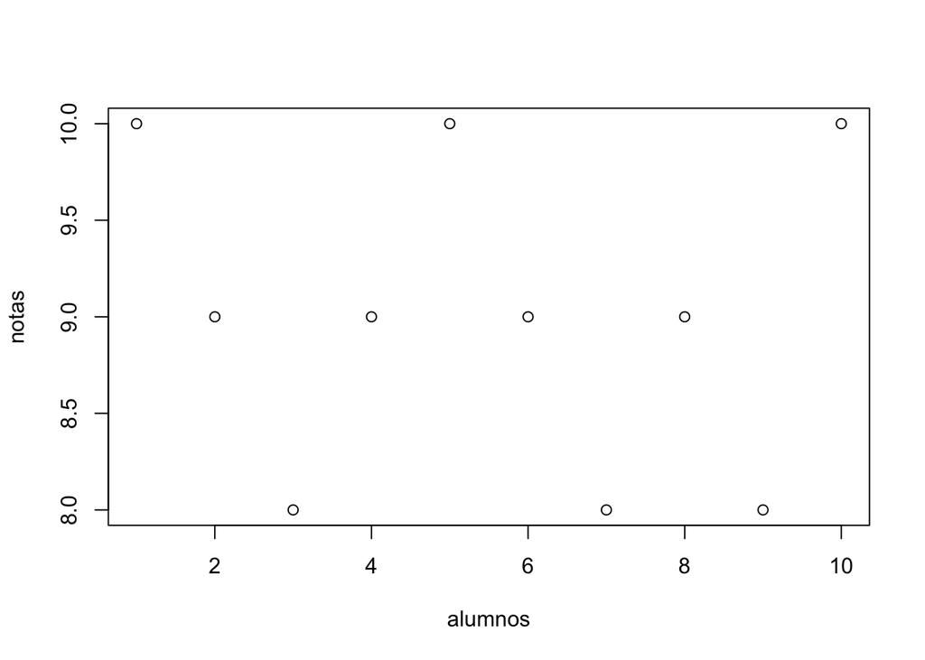

Grafico basico explicando el uso del plot

```r
   alumnos = c(1:10)
   notas = c(10,9,8,9,10,9,8,9,8,10)
   plot(alumnos,notas)
```

Si no incorporamos algun vector `y` , `Rr nos va a tomar el parametro`x`como si fuese el vector de datos`y`

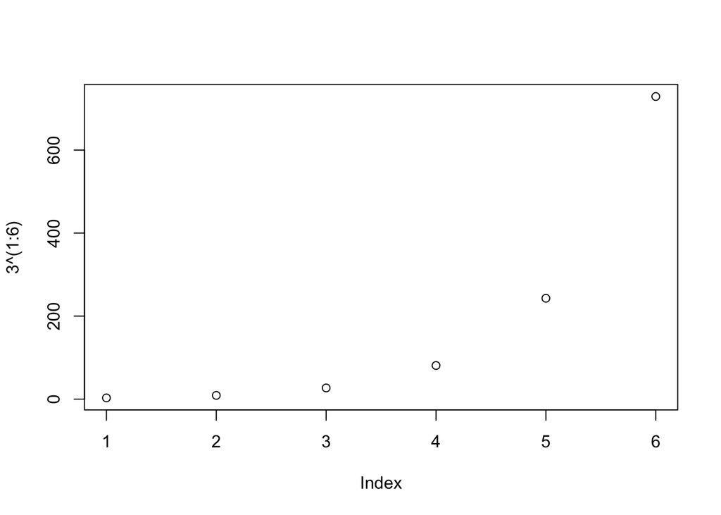

```r
plot(3^(1:6))
```

Si queremos representa una funcion $f(x)$:

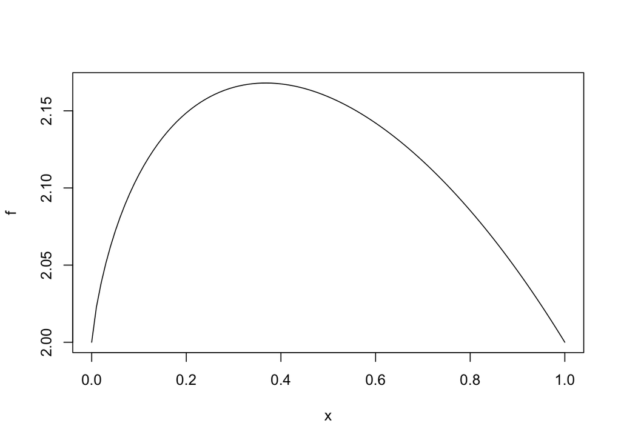

```r
f <- function(x){ 3-sqrt(x)^x }
plot(f)
```

Si queremos representar una esccala logaritmica.

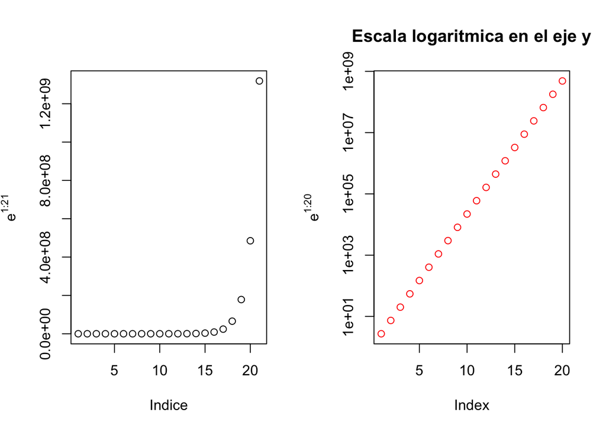

```r
par(mfrow = c(1,2))
plot = plot(exp(1:21), xlab = "Indice", ylab = expression(e^{1:21},
                                                          main = "Escala Lineal",))
plotLog = plot(exp(1:20), log = "y", xlab = "Index", ylab = expression(e^{1:20}), main = "Escala logaritmica en el eje y",col="red")
```

# GRAFICA CON PARAMETROS

```r
n = 1:20
fib = (1/sqrt(5))*((1+sqrt(5))/2)^n - (1+n/sqrt(5^n))*((1-sqrt(5))/2)^n
fib
```

```
##  [1]    1.618034    0.636068    2.193839    2.896006    5.057910    7.966519
##  [7]   13.019902   20.987961   34.007357   54.995479   89.002786  143.998281
## [13]  233.001062  376.999344  610.000405  986.999750 1597.000155 2583.999904
## [19] 4181.000059 6764.999963
```

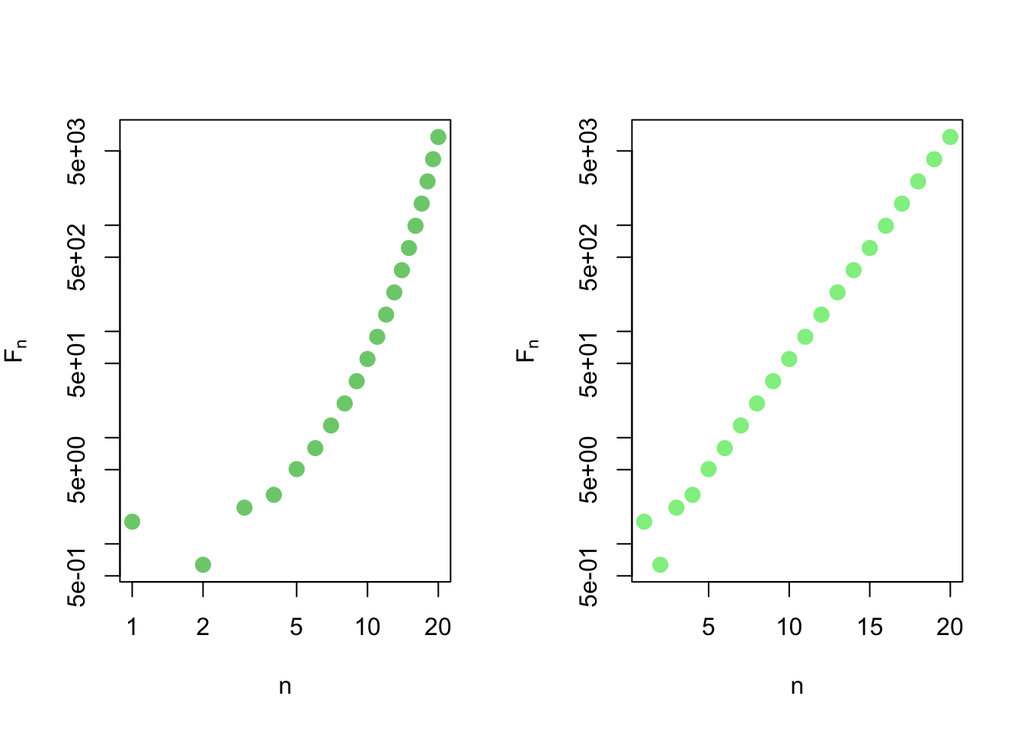

```r
par(mfrow = c(1,2))
plot(fib, xlab = "n", ylab= expression(F[n]),col="palegreen3",pch = 20, cex = 2, bg = "black", log = "xy")
plot(fib, xlab = "n", ylab= expression(F[n]),col="palegreen2",pch = 20, cex = 2, bg = "black", log = "y")
```

```r
par(mfrow = c(1,1))
```

# GRAFICA 02 CON PARAMETROS

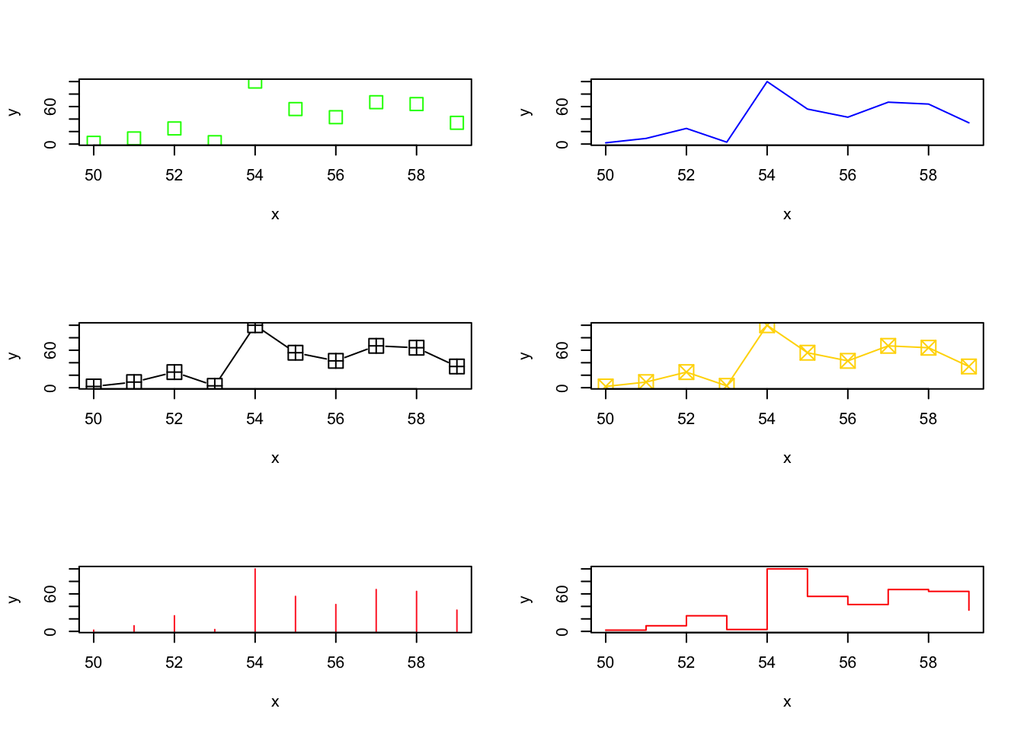

```r
par(mfrow = c(3,2))
x = c(50:59)
y = c(2,9,25,3,100,56,43,67,64,34)
plot(x,y, pch = 22, cex = 2 , col="green",type = "p")
plot(x,y, pch = 20, cex = 2 , col="blue",type = "l")
plot(x,y, pch = 12, cex = 2 , col="black",type = "b")
plot(x,y, pch = 7, cex = 2 , col="gold",type = "o")
plot(x,y, pch = 21, cex = 2 , col="firebrick1",type = "h")
plot(x,y, pch = 18, cex = 2 , col="red",type = "s")
```

```r
par(mfrow = c(1,1))
```

# GRAFICA 03 CON PARAMETROS

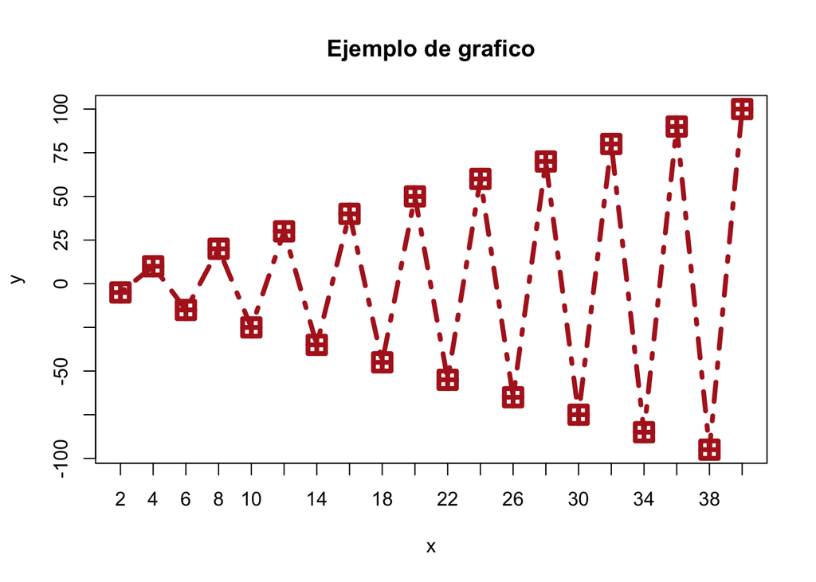

```r
x = (2*(1:20))
y = (-1)^(1:20)*5*(1:20)
plot(x,y, main = "Ejemplo de grafico",pch = 12, cex = 2, type = "o",lty = 4, lwd= 4,xaxp=c(0,40,20), yaxp = c(-100,100,8), col = "firebrick")
```

#Agregando elementos a un grafico

# Agregando puntos y rectas

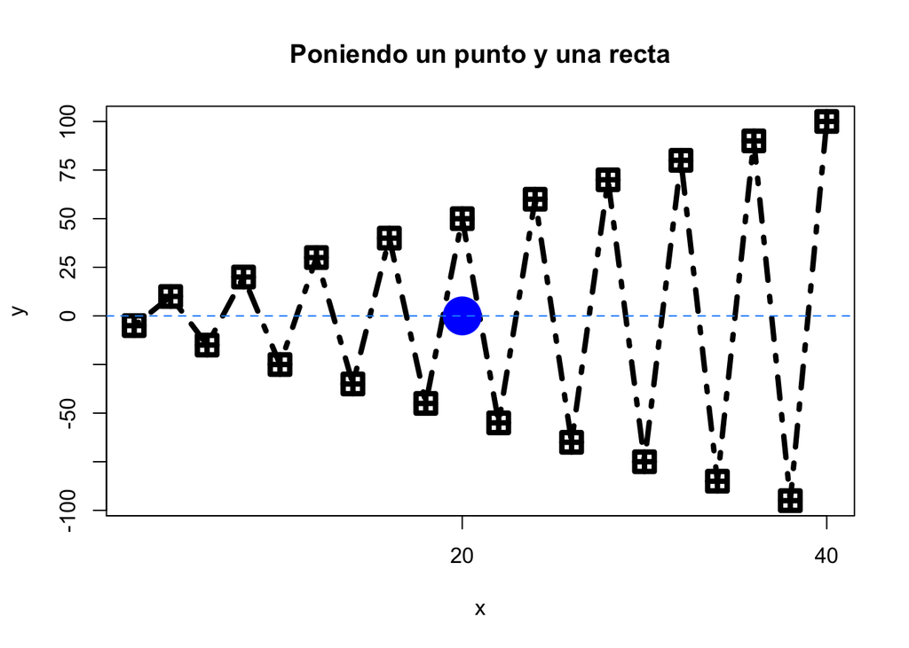

```r
x = (2*(1:20))
y = (-1)^(1:20)*5*(1:20)
plot(x,y, main = "Poniendo un punto y una recta",pch = 12, cex = 2, type = "o",lty = 4, lwd= 4,xaxp=c(0,40,2), yaxp = c(-100,100,8))

points(20,0, col = "blue", cex = 4, pch=16)
abline (h = 0, lty = 2, col = "dodgerblue")
```

#Ejemplo

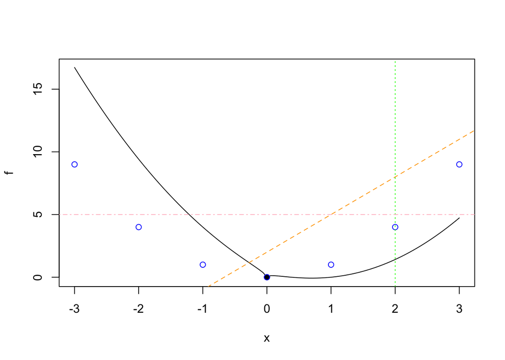

```r
f <- function(x){
  x^2-2*x + sqrt(abs(x))
}
plot(f, xlim = c(-3,3))
points(0,0, pch= 19)
points(-3:3, (-3:3)^2,col = "blue")
abline(2,3,lty = "dashed", col = "orange")
abline(v=2, lty = "dotted", col= "green")
abline(h=5,lty = "dotdash",col="pink" )
```

# Añadir texto a nuestro grafico *`text(x,y,labels= "...")`- Añade en el punto de cordenadas $(x,y)$ el texto especificado como argumento de labels - `pos`- Permite indicar la posicion del texto alrededor de las coordenadas **IMPORTANTE** - 1 = Abajo - 2 = Izquierda - 3 = Arriba - 4 = Derecha - 5 = Izquierda

# EJEMPLO

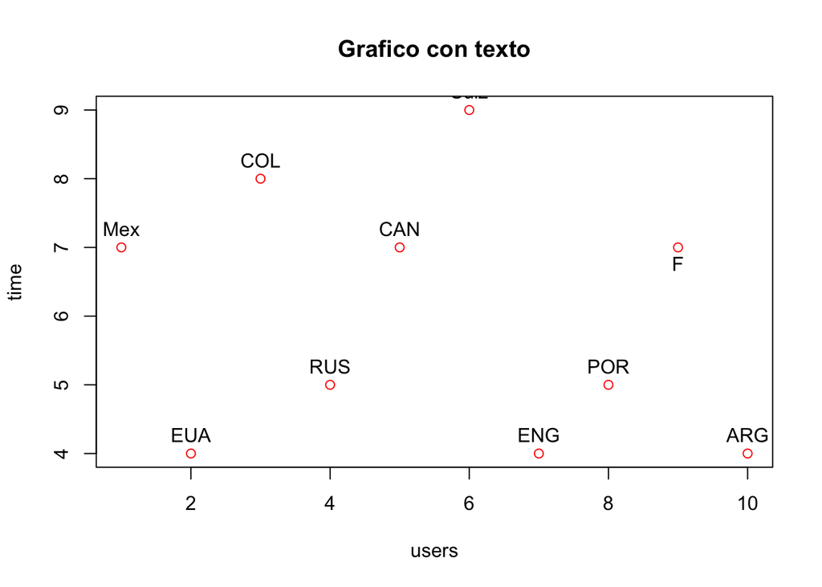

```r
users = c(1:10)
time = c(7,4,8,5,7,9,4,5,7,4)
plot(users,time, main = "Grafico con texto",col = "red")
text(users,time, labels = c("Mex","EUA","COL","RUS","CAN","Suiz","ENG","POR","F","ARG"),
pos = c(rep(3,times=8),1,3))
```

# EJEMPLO:

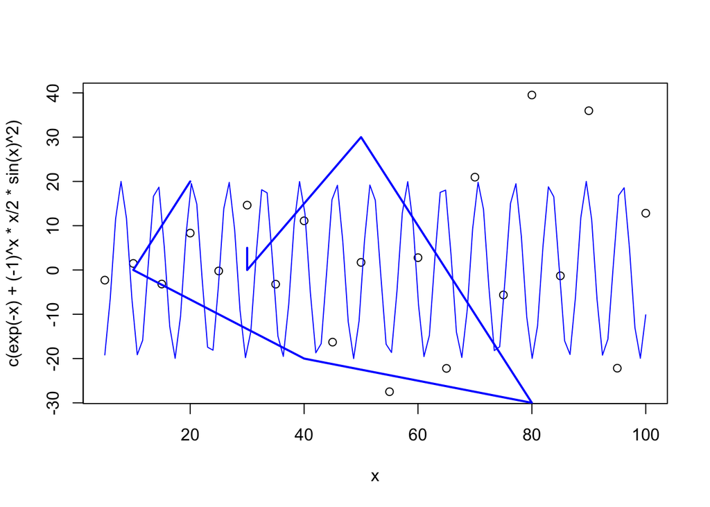

```r
x = c(5*(1:20))
plot(x,c(exp(-x)+(-1)^x*x/2*sin(x)^2))
lines(c(20,10,40,80,50,30,30),c(20,0,-20,-30,30,0,5),lwd = 2,col = "blue")
curve(20*sin(x), add = TRUE , col = "blue")
```

# Leyendas de valores

- `legend(posicion, legend = ...)`para añadir una leyenda *`legend`- Contiene el valor de una leyenda

#Ejemplo

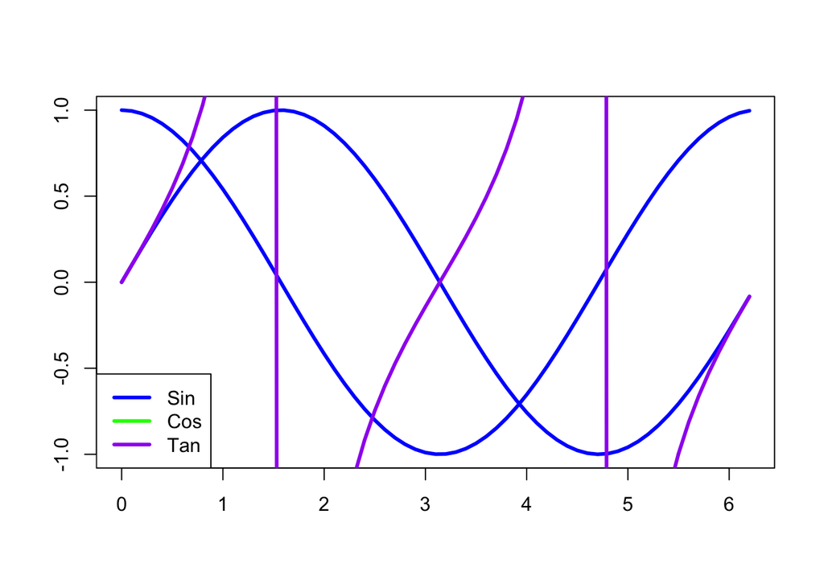

```r
x = seq(0,2*pi,0.1)
plot(x,sin(x),type ="l",col="blue",lwd=3,xlab="",ylab="")
lines(x,cos(x),col="blue",lwd=3)
lines(x,tan(x), col = "purple",lwd=3)
legend("bottomleft",col=c("blue","green","purple"), legend=c("Sin","Cos","Tan"),lwd=3,bty="l")
```

# Segementos,flechas,simbolos y poligonos

- `segments` - Sirve para añadir segmentos a un grafico existente
- `arrows` - Sirve para aadir flechas a un grafico existente
- `symbols` -S irve para añadir simbolos a un grafico
- `polygon`- Sirve para añadir poligonos cerrados especificando sus vertices a un grado existente

# EJEMPLO

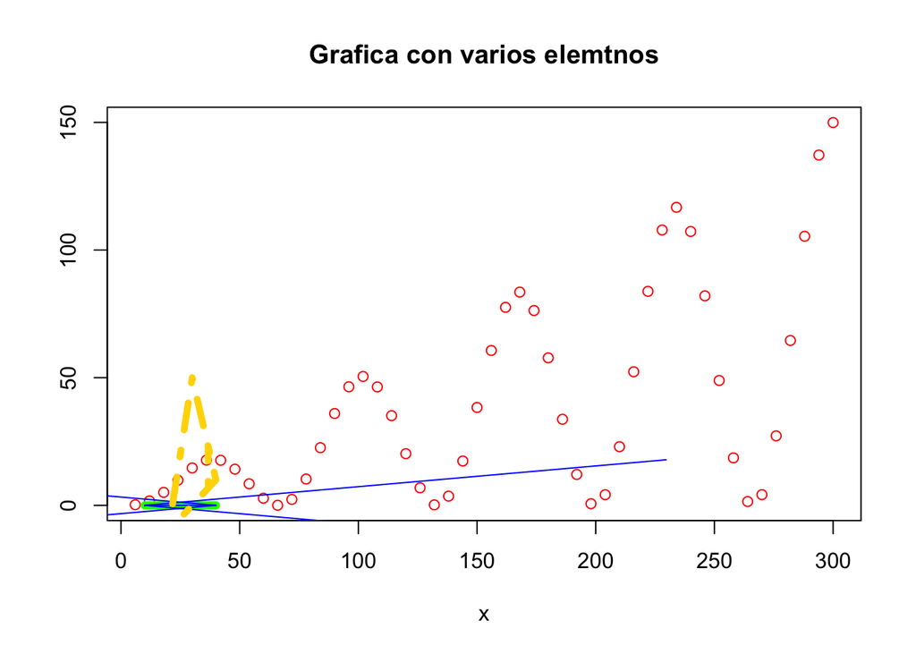

```r
x = c(6*(1:50))
plot(x,c(exp(-x)+(-1)^x*x/2*sin(x)^2), ylab= "",main = "Grafica con varios elemtnos",col = "red")
segments(10,0,40,0,col= "green", lwd= 6)
arrows(10,0,40,0,col= "blue", length = 4, angle = 5, code = 3)
polygon(c(20,30,40),c(-10,50,10), col = "gold", density = 3, angle = 90, lty = 4, lwd=5)
```